# Forecasting Foreign Aid Amounts

Ben Arancibia

May 22, 2015

# Introduction

Developing countries face challenges in accessing up-to-date information about aid, development, and humanitarian flows. This information is needed to plan and manage resources effectively. There is a large movement which allows different stakeholders to publish data on development cooperation activities. The International Aid Transparency Initiative [IATI](http://www.aidtransparency.net/) manages and provides the standard that donors and recipient countries, civil society organizations, and others use to publish and consume data on development cooperation activities.

Assumptions:

- All values are in USD

# Data Workflow

The first step of any analysis is to import the necessary packages. Packages used in this analysis are below.

```r
library(ggplot2) #static visualization
library(dplyr) #data manipulation and connect to database
library(knitr)
library("devtools") #needed to install plotly if you don't have it already

library(plotly) #interactive visualization
library(forecast)
library(lubridate)
library(cluster)
library(fpc)
```

## Importing the CSV

The data was downloaded via the IATI API. The resulting csv was imported into memory to quickly view.

```r
transactions <- read.csv("/users/bcarancibia/transactions_data.csv", header=TRUE)
nrow(transactions)
```

```
## [1] 174512
```

The number of rows is quite large so the first step is to cut it down to only include transactions that are disbursments and commitments. In the transaction.type, fields with C, D, 2, or 3 are commitments and disbursements. First step is to subset the data to see how many rows of data are in the file.

```r
data <- subset(transactions, transaction.type =="C" | transaction.type =="D" | transaction.type ==2 | transaction.type == 3)
nrow(data)
```

```
## [1] 132510
```

```r
nrow(transactions) - nrow(data)
```

```
## [1] 42002
```

The number of rows subsetted into the the “data” dataframe is 42,002 less with a total of 132,510 rows in the data dataframe. The next step is to filter out only the necessary fields. Currently, there are 74, the key fields necessary are:

- transaction date
- default currency
- transaction value
- IATI identifier
- Reporting Org
- Title
- Start Planned
- End Planned
- Start Actual
- End Actual
- Recipient Country
- Sector

```r
data <- data[c("transaction.date","transaction.value", "iati.identifier", "reporting.org", "title", "start.planned", "end.planned", "start.actual", "end.actual", "recipient.country", "sector")]
```

The final step in the data clean up is to take a look at transactions values.

```r
summary(data$transaction.value)
```

```
##       Min.    1st Qu.     Median       Mean    3rd Qu.       Max.
## -1.458e+08  1.182e+03  4.845e+04  2.738e+06  4.597e+05  2.492e+10
##       NA's
##         88
```

There are negative transaction values, which means some of the transactions are being used to pay off loans. There are also 88 NA’s as a result, there is a final subset to remove the 88 NA’s.

```r
data <- subset(data, transaction.value!="NA")
```

Also, there needs to be a removal of blank transactions dates.

```r
data <- subset(data, transaction.date!="")
```

Doing this final subset allows 93, 531 rows of data and take a look at the aid amounts per country.

```r
plt <- ggplot(data, aes(recipient.country, transaction.value)) +
                geom_bar(stat = 'identity') +
                theme_minimal() + theme(axis.text.x = element_text(angle = 45, hjust = 1))


py <- plotly()
py$ggplotly(plt, session='knitr')
```

```
## Estimated Draw Time Too LongThe draw time for this plot will be slow for all clients.
```

[interactive chart not shown]

# Forecasting

One of the first things that need to do is plot transaction values based on dates.

```r
by.date<- group_by(data, transaction.date)
summary.date <- summarise(by.date, count.date = n(),
                               total.date = sum(transaction.value))


order.date.total <- summary.date[order(-summary.date$total.date),]

order.date <- summary.date[order(-summary.date$count.date),]
```

One thing to notice is that the in the largest number of transactions occur at the end of the year.

```r
knitr::kable(head(order.date))
```

| transaction.date | count.date | total.date |
| --- | --- | --- |
| 12/31/12 | 5424 | 44472814950 |
| 12/31/13 | 4972 | 29947082491 |
| 12/31/15 | 4377 | 1414639946 |
| 12/31/14 | 3736 | 2602332709 |
| 6/30/14 | 2307 | 4116645016 |
| 1/1/12 | 1653 | 45984472695 |

```r
knitr::kable(head(order.date.total))
```

| transaction.date | count.date | total.date |
| --- | --- | --- |
| 1/1/12 | 1653 | 45984472695 |
| 12/31/12 | 5424 | 44472814950 |
| 12/31/13 | 4972 | 29947082491 |
| 3/31/14 | 877 | 22543780336 |
| 3/13/13 | 14 | 15111667359 |
| 12/31/09 | 1148 | 8605614791 |

Lets take a look at the data structure, first order the data.

```r
summary.date <- summary.date[order(as.Date(summary.date$transaction.date, format="%m/%d/%Y")),]

plt <- ggplot(summary.date, aes(transaction.date, total.date)) +
                geom_bar(stat = 'identity') +
                theme_minimal() + theme(axis.text.x = element_text(angle = 45, hjust = 1))

#not plotting via date order, why?
py <- plotly()
py$ggplotly(plt, session='knitr')
```

[interactive chart not shown]

```r
lm <- lm(data$transaction.value ~ data$reporting.org + data$recipient.country, data=data)

summary(lm)
```

```
##
## Call:
## lm(formula = data$transaction.value ~ data$reporting.org + data$recipient.country,
##     data = data)
##
## Residuals:
##        Min         1Q     Median         3Q        Max
## -1.040e+09 -2.082e+06 -4.525e+05  5.464e+05  2.388e+10
##
## Coefficients:
##                                                                                         Estimate
## (Intercept)                                                                               148308
## data$reporting.orgAbleChildAfrica                                                        -162266
## data$reporting.orgACORD                                                                    58229
## data$reporting.orgAct4Africa                                                             -393346
## data$reporting.orgActionAid International                                                 195046
## data$reporting.orgActionAid UK                                                          -4161027
## data$reporting.orgActionAid United Kingdom                                              -1470954
## data$reporting.orgAdaptation Fund                                                        3615324
## data$reporting.orgADD International                                                      -267232
## data$reporting.orgAfrican Development Bank Group                                         6342637
## data$reporting.orgAidData                                                                3832687
## data$reporting.orgAll We Can (formerly Methodist Relief and Development Fund)            -298011
## data$reporting.orgAmref Flying Doctors                                                   -169324
## data$reporting.orgAmref Health Africa - UK                                               -262076
## data$reporting.orgAPT Action on Poverty                                                  -380422
## data$reporting.orgBelgian Development Cooperation                                         679156
## data$reporting.orgBill and Melinda Gates Foundation                                       896382
## data$reporting.orgBMZ                                                                    1717836
## data$reporting.orgBRAC International                                                     -213167
## data$reporting.orgBritish Red Cross                                                      1130720
## data$reporting.orgBuild Africa                                                           -378751
## data$reporting.orgCAFOD                                                                  -346078
## data$reporting.orgCarers Worldwide                                                      -1656681
## data$reporting.orgCATHOLIC RELIEF SERVICES                                               6031410
## data$reporting.orgCDC Group plc                                                            76388
## data$reporting.orgChildHopeUK                                                            -510791
## data$reporting.orgChristian Aid                                                           -89754
## data$reporting.orgClimate Investment Funds-Clean Technology Fund                        21471184
## data$reporting.orgClimate Investment Funds-Strategic Climate Fund                        8491730
```

[output cut: 596 more lines]

```
## data$recipient.countryHaiti                                                           *
## data$recipient.countryHonduras
## data$recipient.countryKyrgyzstan                                                      .
## data$recipient.countryMadagascar
## data$recipient.countryMoldova, Republic Of
## data$recipient.countryNepal
## data$recipient.countrySouth Sudan
## data$recipient.countryTimor-Leste
## data$recipient.countryUganda
## ---
## Signif. codes:  0 '***' 0.001 '**' 0.01 '*' 0.05 '.' 0.1 ' ' 1
##
## Residual standard error: 117400000 on 93405 degrees of freedom
## Multiple R-squared:  0.02368,    Adjusted R-squared:  0.02237
## F-statistic: 18.12 on 125 and 93405 DF,  p-value: < 2.2e-16
```

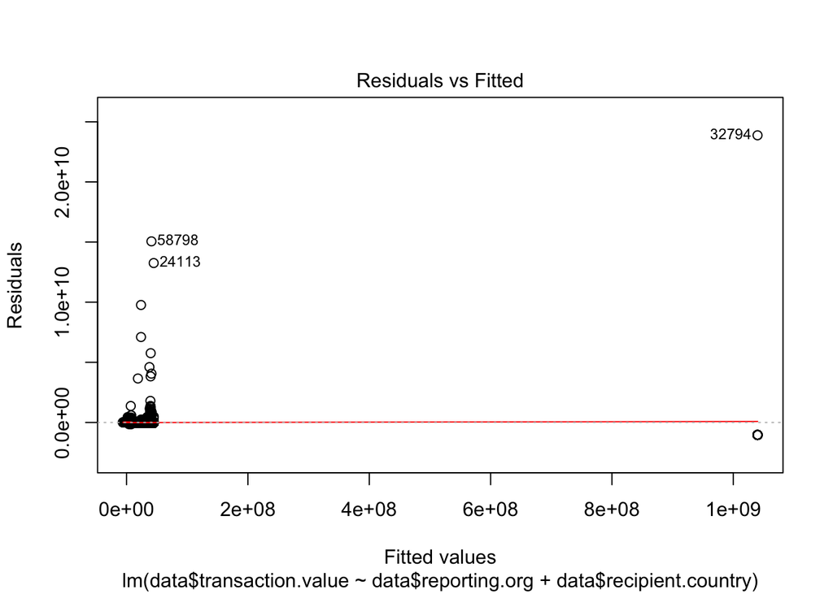

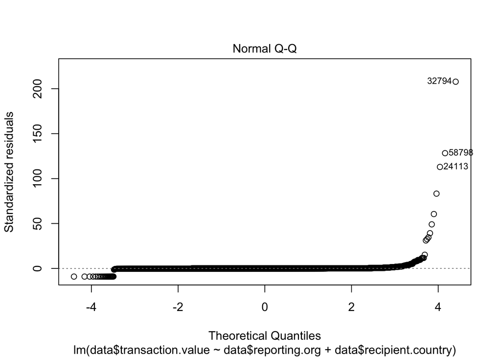

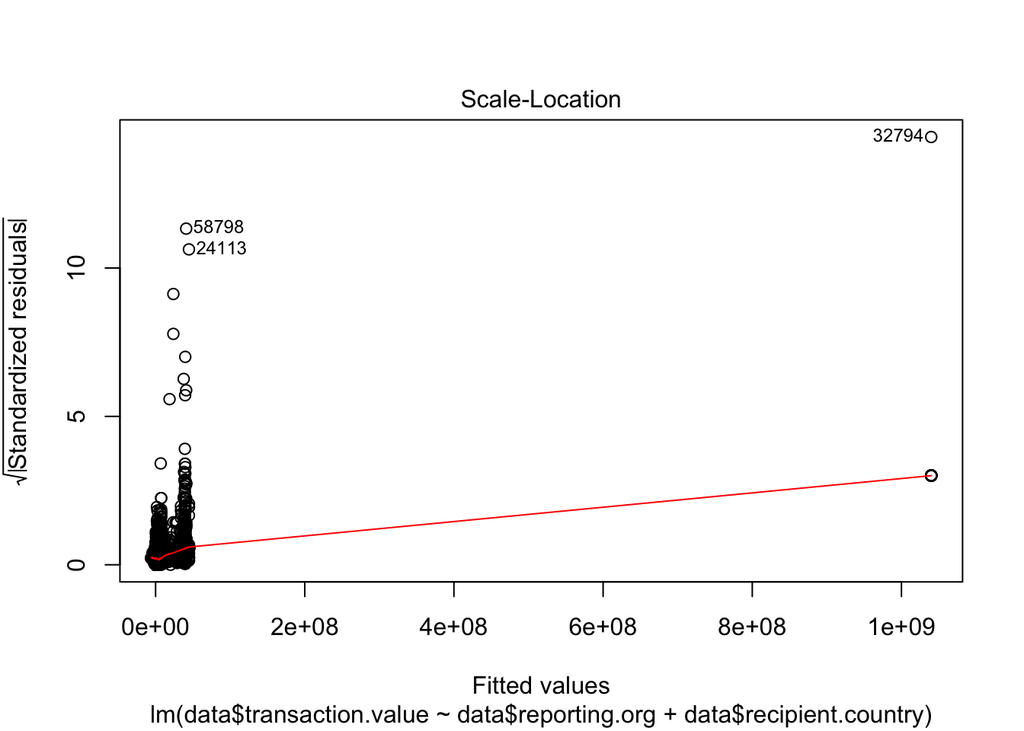

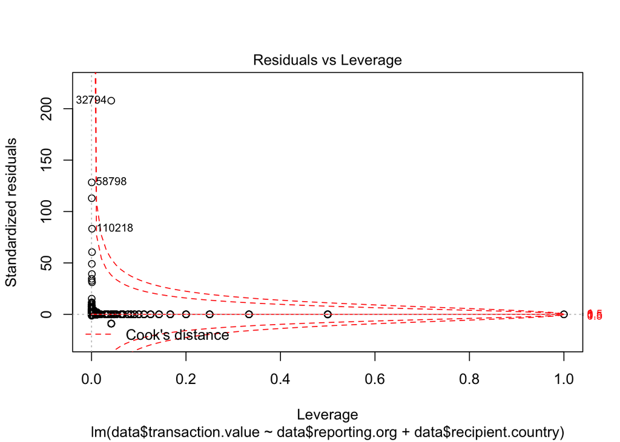

```r
plot(lm)
```

Look at the regression of transactions values and dates.

```r
lm.date <- lm(data$transaction.value ~ data$transaction.date, data=data)

summary(lm.date)
```

```
##
## Call:
## lm(formula = data$transaction.value ~ data$transaction.date,
##     data = data)
##
## Residuals:
##        Min         1Q     Median         3Q        Max
## -1.079e+09 -2.812e+06 -6.380e+05 -1.395e+05  2.491e+10
##
## Coefficients:
##                                 Estimate Std. Error t value Pr(>|t|)
## (Intercept)                    1.552e+05  7.523e+06   0.021 0.983544
## data$transaction.date1/1/01    4.969e+05  1.095e+07   0.045 0.963815
## data$transaction.date1/1/02    4.374e+05  1.074e+07   0.041 0.967504
## data$transaction.date1/1/03    9.206e+05  1.006e+07   0.092 0.927073
## data$transaction.date1/1/04    6.239e+05  9.902e+06   0.063 0.949764
## data$transaction.date1/1/05    9.050e+05  1.037e+07   0.087 0.930455
## data$transaction.date1/1/06    1.417e+06  1.050e+07   0.135 0.892638
## data$transaction.date1/1/07    5.476e+06  1.136e+07   0.482 0.629691
## data$transaction.date1/1/08    4.382e+06  9.628e+06   0.455 0.649046
## data$transaction.date1/1/09    2.913e+06  9.352e+06   0.311 0.755451
## data$transaction.date1/1/10    4.115e+06  8.544e+06   0.482 0.630023
## data$transaction.date1/1/11    3.180e+06  8.260e+06   0.385 0.700242
## data$transaction.date1/1/12    2.766e+07  8.076e+06   3.425 0.000614 ***
## data$transaction.date1/1/13    1.940e+06  8.425e+06   0.230 0.817900
## data$transaction.date1/1/14    2.104e+05  8.789e+06   0.024 0.980899
## data$transaction.date1/1/15    1.841e+06  1.704e+07   0.108 0.913979
## data$transaction.date1/1/16   -1.466e+05  8.478e+07  -0.002 0.998621
## data$transaction.date1/10/03  -1.457e+04  1.197e+08   0.000 0.999903
## data$transaction.date1/10/08  -5.995e+04  1.197e+08  -0.001 0.999600
## data$transaction.date1/10/11   1.037e+06  3.397e+07   0.031 0.975646
## data$transaction.date1/10/12   1.395e+06  3.174e+07   0.044 0.964943
## data$transaction.date1/10/13   3.505e+06  3.529e+07   0.099 0.920882
## data$transaction.date1/10/14   1.598e+07  4.051e+07   0.395 0.693198
## data$transaction.date1/11/05   1.448e+05  1.197e+08   0.001 0.999034
## data$transaction.date1/11/06  -5.517e+04  1.197e+08   0.000 0.999632
## data$transaction.date1/11/10   1.023e+05  1.197e+08   0.001 0.999318
## data$transaction.date1/11/11   6.959e+06  3.397e+07   0.205 0.837662
## data$transaction.date1/11/12   1.615e+07  3.397e+07   0.475 0.634460
## data$transaction.date1/11/13  -5.634e+04  1.197e+08   0.000 0.999624
```

[output cut: 2562 more lines]

```
## data$transaction.date9/8/12    6.445e+06  8.478e+07   0.076 0.939401
## data$transaction.date9/8/14    1.315e+06  2.774e+07   0.047 0.962204
## data$transaction.date9/9/05    3.845e+06  1.197e+08   0.032 0.974368
## data$transaction.date9/9/09    1.422e+06  5.394e+07   0.026 0.978967
## data$transaction.date9/9/10    6.346e+06  6.019e+07   0.105 0.916024
## data$transaction.date9/9/11    8.404e+05  3.679e+07   0.023 0.981773
## data$transaction.date9/9/12    3.622e+06  6.019e+07   0.060 0.952016
## data$transaction.date9/9/13    8.844e+05  2.342e+07   0.038 0.969876
## data$transaction.date9/9/14    6.817e+05  3.397e+07   0.020 0.983987
## ---
## Signif. codes:  0 '***' 0.001 '**' 0.01 '*' 0.05 '.' 0.1 ' ' 1
##
## Residual standard error: 119400000 on 90931 degrees of freedom
## Multiple R-squared:  0.01637,    Adjusted R-squared:  -0.01174
## F-statistic: 0.5824 on 2599 and 90931 DF,  p-value: 1
```

# Clustering Analysis

Cluster Analysis is the task of grouping a set of objects in such a way that objects in the same group (called a cluster) are more similar (in some sense or another) to each other than to those in other groups (clusters). It is a main task of exploratory data mining, and a common technique for statistical data analysis.

K-means clustering is a method of vector quantization, originally from signal processing. K-means clustering aims to partition n observations into k clusters in which each observation belongs to the cluster with the nearest mean, serving as a prototype of the cluster.

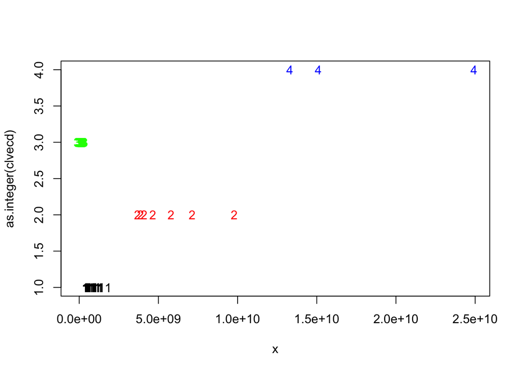

```r
clus <- kmeans(data$transaction.value, centers=4)

plotcluster(data$transaction.value, clus$cluster)
```